# BP PRS and pregnancy complications

```r
knitr::opts_chunk$set(echo = TRUE, warning=FALSE, message=F)
```

**Libraries**

```r
detach("package:pROC", unload=TRUE)
detach("package:forestplot", unload=TRUE)


#Local installation
#install.packages("packages/PBSmodelling_2.68.8.tar.gz", repos=NULL)
#install.packages("packages/PredictABEL_1.2-4.tar.gz", repos=NULL)
install.packages("packages/pROC_1.18.0.tar.gz", repos=NULL)
install.packages("packages/forestplot_2.0.1.tar.gz", repos=NULL)

#survcomp dependences
install.packages("packages/SuppDists_1.1-9.7.tar.gz", repos=NULL)
install.packages("packages/survivalROC_1.0.3.tar.gz", repos=NULL)
install.packages("packages/rmeta_3.0.tar.gz", repos=NULL)
install.packages("packages/bootstrap_2019.6.tar.gz", repos=NULL)
install.packages("packages/survcomp_1.46.0.tar.gz", repos=NULL)

#DescTools & dependences:
install.packages("packages/rootSolve_1.8.2.3.tar.gz", repos=NULL)
install.packages("packages/lmom_2.8.tar.gz", repos=NULL)
install.packages("packages/Exact_3.1.tar.gz", repos=NULL)
install.packages("packages/gld_2.6.4.tar.gz", repos=NULL)
install.packages("packages/expm_0.999-6.tar.gz", repos=NULL)
install.packages("packages/DescTools_0.99.44.tar.gz", repos=NULL)
```

```r
library(tidyverse)
library(survival)   # survival analysis
library(data.table) # fread() function
library(gridExtra)  # plots to grid
library(survminer)  # ggbased visualization and extra diagnostics
library(visdat)     # visualization of tibble and na's
library(tableone)   # Characteristics table
library(compareC)   # Compare c-index
library(Hmisc)
library(PredictABEL) #NRI and IDI
library(pROC)
library(kableExtra) # Pretty tables
library(forestplot)
library(DescTools)  #Pseudo R2
library(survcomp)   #hr.comp2

source('functions_article.R')

fg_pheno_path <- "/finngen/library-red/finngen_R9/phenotype_1.0/data"
data_path <- "data"
fig_path <- "figs5"
```

# 1 Data

## 1.1 Variables

**Endpoints**

- O15_GESTAT_HYPERT, gestational hypertension
- O15_PREECLAMPS, pre-eclampsia

**Polygenic risk scores**

- Female specific SBP polygenic risk score
- Preeclampsia risk score

## 1.2 Download & preprocess data

**Preselect phenotype columns**

Entries of interest are selected from endpoint file are preselected at ‘rather big machine’, because the original phenotype file is very large.

```r
pheno_cols <- fread("fg_pheno_cols.txt", header=FALSE) %>%
  pull(V1)

pheno_tmp <- fread(str_glue("{fg_pheno_path}/finngen_R9_endpoint_1.0.txt.gz")) %>%
  select(all_of(pheno_cols))

fwrite(pheno_tmp, 'data/finngen_R9_preg.tsv.gz', sep='\t')
```

**Load and combine the data**

```r
# We have calculated all PRS scores by FinnGen PRS-CS pipeline.

#PRS score
prs_sbp <- fread("data/ukb_ega_prs/ukb.sbp.female.gwas.tsv.sscore") %>%
  select(IID, SCORE1_AVG) %>%
  rename(FINNGENID = IID, SBP_SCORE = SCORE1_AVG)

prs_prec <- fread("data/ukb_ega_prs/ega2.pe.gwas.tsv.sscore") %>%
  select(IID, SCORE1_AVG) %>%
  rename(FINNGENID = IID, PREC_SCORE = SCORE1_AVG)


#endpoints and covariates
phenotypes <- fread(str_glue("{data_path}/finngen_R9_preg.tsv.gz"), sep = "\t")
  #Should NA's removed from disease variables - they are introduced for the purpose of genetic analysis
  #mutate(across(c(-FINNGENID, -ends_with("_AGE"), -ends_with("_YEAR")),
  #              ~if_else(is.na(.), 0L, .)))


covs_cols <- fread("fg_cov_cols.txt", header=FALSE) %>% pull(V1)
covs_in <- fread(str_glue("/finngen/library-red/finngen_R9/analysis_covariates/R9_COV_V1.FID.txt.gz")) %>%
  rename(FINNGENID = IID) %>%
  select(all_of(covs_cols))

#birth_register
birth_reg <- fread("/finngen/library-red/finngen_R9/birth_and_dvv_register_1.0/data/finngen_R9_birth_dvv_register_mothers.txt.gz") %>%
  select(MOTHER_FINNGENID, MOTHER_AGE, BIRTH_YEAR, PARITY, DURATION_WEEKS, NRO_FETUSES, IVF, ICSI) %>%
  rename(FINNGENID = MOTHER_FINNGENID) %>%
  filter(BIRTH_YEAR >= 1969) %>%
  group_by(FINNGENID) %>%
    mutate(CHILD_COUNT = 1:n()) %>%   #This count refers to nro of child since 1969
  ungroup()                           #Parity would describe the actual first baby

### definition of birth from birth register.
first_birth <- birth_reg %>%
  filter(CHILD_COUNT==1) %>%
  mutate(FIRST = 1L) %>%
  rename(FIRST_AGE = MOTHER_AGE, FIRST_YEAR = BIRTH_YEAR, FIRST_DURATION = DURATION_WEEKS) %>%
  select(FINNGENID, FIRST, FIRST_AGE, FIRST_YEAR, FIRST_DURATION) %>%
  group_by(FINNGENID) %>%
     summarise(FIRST, FIRST_AGE = min(FIRST_AGE), FIRST_YEAR = min(FIRST_YEAR), FIRST_DURATION) %>%
  ungroup()

#combining the data
df <- phenotypes %>%
  left_join(first_birth, by = "FINNGENID") %>%
  mutate(FIRST = if_else(is.na(FIRST), 0L, FIRST)) %>%
  left_join(prs_sbp, by = "FINNGENID") %>%
  left_join(prs_prec, by = "FINNGENID") %>%
  left_join(covs_in, by = "FINNGENID") %>%
  as_tibble() %>%
  mutate_at(c("batch","cohort"),as.factor)

#Number of individuals:
c("Number of individuals:", dim(df)[1])
```

```
## [1] "Number of individuals:" "392423"
```

**Males are removed**. Also endpoint names are simplified.

```r
names_ep <- list("GESTAT_HYPERT", "PREECLAMPS")

#glimpse(df)
#vis_dat(sample_n(df, 10000))

#Filter women and simplify endpointanmes
df.f <- df %>%
  filter(SEX_IMPUTED == 1) %>%  #Only women
  rename_at(vars(contains('O15_')), list(~str_remove(., "O15_"))) %>%
  rename_at(vars(contains('XV_')), list(~str_remove(., "XV_"))) %>%
  rename_at(vars(contains('I9_')), list(~str_remove(., "I9_"))) %>%
  rename_at(vars(contains('E4_')), list(~str_remove(., "E4_"))) %>%
  rename_at(vars(contains('N14_')), list(~str_remove(., "N14_"))) %>%
  rename_at(vars(contains('D3_')), list(~str_remove(., "D3_"))) %>%

#Include gestational diabetes to diabetes
  mutate(DIABETES_ALL = if_else(DIABETES == 1 | GEST_DIABETES == 1, 1L, 0L,)) %>%
  rowwise() %>%
    mutate(DIABETES_ALL_AGE = min(DIABETES_AGE, GEST_DIABETES_AGE),
           DIABETES_ALL_YEAR = case_when(!is.na(DIABETES_YEAR) & !is.na(GEST_DIABETES_YEAR) ~ min(DIABETES_YEAR, GEST_DIABETES_YEAR),
                                         !is.na(DIABETES_YEAR) ~ DIABETES_YEAR,
                                         !is.na(GEST_DIABETES_YEAR) ~ GEST_DIABETES_YEAR)) %>%
             ungroup()


#vis_dat(sample_n(df.f, 10000))

#Number of individuals:
c("Number of women:",dim(df.f)[1])
```

```
## [1] "Number of women:" "210870"
```

We will **end the followup at the age of 55 years**.

```r
#FU_END_AGE and PREGNANCY_BIRTH variables modifed according new followup time
df.f <- df.f %>%
  mutate(FU_END_AGE = if_else(FU_END_AGE>55, 55, FU_END_AGE),
         PREGNANCY_BIRTH = if_else(PREGNANCY_BIRTH_AGE > 55, as.integer(0), PREGNANCY_BIRTH),
         PREGNANCY_BIRTH_AGE = if_else(PREGNANCY_BIRTH_AGE > 55, 55, PREGNANCY_BIRTH_AGE))

#endpoint events and ages modified according new followup time
for(ep in unlist(names_ep)) {
  df.f <- df.f %>%
    mutate(!!ep := if_else(get(str_glue("{ep}_AGE")) > 55, as.integer(0), get(ep)),
           !!(str_glue("{ep}_AGE")) := if_else(get(str_glue("{ep}_AGE")) > 55, 55, get(str_glue("{ep}_AGE")))  )
}
```

**Sex-specific Polygenic risk score** is **scaled** (variable SBP_SCALED) and **categorized** (variable SBP_CAT) using values from remaining women.

```r
my_probs = c(0,0.025,0.2,0.8,0.975,1)
my_labels =  c("<2.5%","2.5-20%","20-80%","80-97.5%",">97.5%")

df.f <- df.f %>%
  mutate(
    SBP_SCALED = scale(SBP_SCORE)[,1],
    PREC_SCALED = scale(PREC_SCORE)[,1],
    SBP_CAT = cut(SBP_SCORE, breaks=quantile(df.f$SBP_SCORE, probs = my_probs),
                         labels=my_labels, include.lowest = T),
    PREC_CAT = cut(PREC_SCORE, breaks=quantile(df.f$PREC_SCORE, probs = my_probs),
                         labels=my_labels, include.lowest = T)
    )
```

**Only women with pregnancy** are included to the analysis.

```r
#Only persons with pregnancy

df.p <- df.f %>%
  filter(FIRST==1)
```

## 1.3 Create clinical covarariates & DIFF-variable

**New age variable ‘INDEX_AGE’**

For cases patiant ‘INDEX_AGE’ is age of first preeclampsia and for controls its the first pregnancy. Covariate events before preeclampsia are defined (*_PRE). In addition, variable ‘IS_FIRST’ defines whether first preeclampsia was in first pregnancy and ‘IS_MULTIPLE’ whether it is multiple pregnancy.

There was no column for ‘D3_OTHTHROMBOPHILIA’.

```r
#names_outcomes = list("GESTAT_HYPERT", "PREECLAMPS", "ECLAMPSIA")
names_outcomes = list("GESTAT_HYPERT", "PREECLAMPS", "ECLAMPSIA", "PRE_OR_ECLAMPSIA", "ABORT_SPONTAN", "PLAC_PREMAT_SEPAR", "PRETERM", "LABOUR_INTRAPART_HAEMORRH", "LABOUR_FETAL_STRESS", "LABOUR_UMBILICAL", "POSTPART_HEAMORRH", "MEMBR_PREMAT_RUPT", "AMNIOT_OTHER")

#clin_covs <- c("INDEX_AGE", "IS_MULTIP", "IS_IVF", "HYPTENS_PRE", "OBESITY_PRE", "DIABETES_ALL_PRE", "RENFAIL_PRE", "CHD_PRE", "PAD_PRE", "STR_PRE")
clin_covs <- c("INDEX_AGE", "IS_MULTIP", "IS_IVF", "HYPTENS_PRE", "OBESITY_PRE", "DIABETES_ALL_PRE", "RENFAIL_PRE")
clin_covs_age <- c("HYPTENS_AGE", "OBESITY_AGE", "DIABETES_ALL_AGE", "RENFAIL_AGE", "CHD_AGE", "PAD_AGE", "STR_AGE")
gen_covs <- c("batch", "BL_YEAR","PC1", "PC2", "PC3", "PC4", "PC5", "PC6", "PC7", "PC8","PC9", "PC10")
clin_covs_prelim <- c("HYPTENS", "OBESITY", "DIABETES_ALL", "RENFAIL")


#list.df.p <- vector(mode = "list", length = 3)
list.df.p = list(GESTAT_HYPERT=NULL, PREECLAMPS=NULL, ECLAMPSIA = NULL, PRE_OR_ECLAMPSIA=NULL, ABORT_SPONTAN=NULL, PLAC_PREMAT_SEPAR=NULL, PRETERM=NULL, LABOUR_INTRAPART_HAEMORRH=NULL, LABOUR_FETAL_STRESS=NULL, LABOUR_UMBILICAL=NULL, POSTPART_HEAMORRH=NULL, MEMBR_PREMAT_RUPT=NULL, AMNIOT_OTHER=NULL)
outcome = "GESTAT_HYPERT"
#outcome = "PREECLAMPS"

 for (outcome in unlist(names_outcomes))
{

  tmp <- df.p %>%
     left_join(birth_reg, by="FINNGENID") %>%
     select(FINNGENID, MOTHER_AGE, DURATION_WEEKS, PARITY, CHILD_COUNT, NRO_FETUSES, IVF, ICSI, contains(outcome), contains("FIRST")) %>%
     mutate(PREG_START_AGE = if_else(!is.na(DURATION_WEEKS), MOTHER_AGE - DURATION_WEEKS/52, MOTHER_AGE - 0.75), TMP = DURATION_WEEKS/52)

  #cases
  tmp_cases <- tmp %>%
     filter(get(outcome) == 1) %>%
     mutate(INDEX_AGE = get(str_glue("{outcome}_AGE")),  #This line differs for cases and controls!!
            DIFF_WEEKS = (INDEX_AGE - PREG_START_AGE)*52,
            DIFF_TMP = DIFF_WEEKS) %>%  #Mock variable for 'slice'
   #Set DIFF as NA if not same pregnancy
   mutate(DIFF_WEEKS = if_else((INDEX_AGE >= PREG_START_AGE) & (INDEX_AGE <= MOTHER_AGE + 1/12), DIFF_WEEKS, NA_real_)) %>%
   #Horrible hack, but I did not come with better idea.  We will primarly use lines linked with pregnancy and secondarily other lines.
   mutate(DIFF_TMP = if_else(is.na(DIFF_WEEKS), abs(DIFF_TMP)+100, abs(DIFF_TMP)) )  %>%
   #filter(INDEX_AGE >= PREG_START_AGE, INDEX_AGE <= MOTHER_AGE + 1/12) %>% #Exclude if not same pregnancy
   group_by(FINNGENID) %>% #Select the line with smallest time difference
     slice(which.min(DIFF_TMP)) %>%
   ungroup()

   #controls
   tmp_controls <- tmp %>%
     filter(get(outcome) == 0) %>%
     mutate(INDEX_AGE = FIRST_AGE,  #This line differs for cases and controls!!
             DIFF_WEEKS = (INDEX_AGE - PREG_START_AGE)*52) %>%
     #Exclude if not same pregnancy
     filter(INDEX_AGE >= PREG_START_AGE, INDEX_AGE <= MOTHER_AGE + 1/12) %>%  #Only 'current pregnancy' is left.
     group_by(FINNGENID) %>%   #Select the line with smallest time difference
       slice(which.min(abs(DIFF_WEEKS))) %>%
     ungroup()

   tmp_br <- bind_rows(tmp_cases, tmp_controls) %>%
     arrange(FINNGENID) %>%
     mutate(IS_MULTIP = if_else(NRO_FETUSES >=2, 1L, 0L),
            IS_IVF = if_else(IVF==1 | ICSI==1, 1L, 0L),
            IS_IVF = if_else(is.na(IS_IVF), 0L, IS_IVF),  #Remove NA's.
            IS_FIRST = if_else(PARITY ==1, 1L, 0L)) %>%
     select(FINNGENID, PREG_START_AGE, INDEX_AGE, DIFF_WEEKS, IS_MULTIP, IS_IVF, IS_FIRST)

   #Tähän asti index-age on määritelty kaikille ja lukumäärät mätsäävät.

  #New variables
  df.p2 <-df.p %>%
    left_join(tmp_br, by = "FINNGENID") %>%
    mutate( #AGE_SCALED = scale(INDEX_AGE),
           "{outcome}_NA_AGE" := if_else(get(outcome) == 1, get(str_glue("{outcome}_AGE")), NA_real_) )  %>%   #age for the summary

    #Keep disease covariate, only if before event
     mutate(across(all_of(clin_covs_prelim),
                list(PRE=~if_else(get(str_glue("{cur_column()}_AGE")) < INDEX_AGE, ., 0L))))  %>%

    select(FINNGENID, contains("PREG"), contains("FIRST"), INDEX_AGE, contains("DIFF"),
           contains(outcome), ends_with("SCALED"), ends_with("_CAT"),
           all_of(clin_covs), all_of(clin_covs_age), all_of(gen_covs)) %>%
    #select(FINNGENID, GESTAT_HYPERT, INDEX_AGE, contains("GESTAT_HYPERT")) %>%
    filter(!is.na(INDEX_AGE))

   list.df.p[[outcome]] = df.p2


  #df.p2 %>%
  #  mutate_if(is.integer, as.factor) %>%
  #  mutate_at(vars(contains('_PRE'), IS_MULTIP, IS_IVF), as.factor) %>%
  #  summary()

}
```

## 1.4 Characteristics

**Percentage of pregnant women**

and **average age** for the first pregnancy.

```r
tmp1 <- df.f %>%
  summarise(N_fem=n(),N_preg=sum(FIRST), preg_perc = mean(FIRST)*100)

tmp2 <- df.p %>%
  summarise(preg_age = mean(FIRST_AGE), preg_age_sd = sd(FIRST_AGE))

cbind(tmp1,tmp2)%>%
  knitr::kable(digits=2) %>%
  kable_styling(full_width=F, position="left") %>%
  kable_classic(position="left") %>%
  row_spec(0,bold=TRUE)
```

| N_fem | N_preg | preg_perc | preg_age | preg_age_sd |
| --- | --- | --- | --- | --- |
| 210870 | 141298 | 67.01 | 27.12 | 5.15 |

**Correlation, scores:**

```r
cor(df.p$SBP_SCALED, df.p$PREC_SCALED)
```

```
## [1] 0.08504352
```

**Characteristics**

```r
cont_vars <- c("INDEX_AGE")
bin_vars <- c("IS_MULTIP", "IS_IVF", "HYPTENS_PRE", "OBESITY_PRE", "DIABETES_ALL_PRE", "RENFAIL_PRE")
names_outcomes = list("GESTAT_HYPERT", "PREECLAMPS")

lapply(names_outcomes, function(outcome){

  bind_rows(n_to_chartable(outcome,list.df.p[[outcome]]),
            contvar_to_chartable(cont_vars, outcome, list.df.p[[outcome]]),
            binvar_to_chartable(bin_vars, outcome, list.df.p[[outcome]]))

}) %>% setNames(names_outcomes) %>%
  do.call(cbind,.)  %>%
  select(-PREECLAMPS.Characteristics) %>%
  mutate_all(~str_replace(., "^[0-4] .*", "<5")) %>%
  knitr::kable() %>%
  kable_classic() %>%
  row_spec(0,bold=TRUE)
```

| GESTAT_HYPERT.Characteristics | GESTAT_HYPERT.Case | GESTAT_HYPERT.Control | PREECLAMPS.Case | PREECLAMPS.Control |
| --- | --- | --- | --- | --- |
| N | 8488 | 129829 | 6643 | 129711 |
| INDEX_AGE, mean +/- SD | 30.1 +/- 5.7 | 27.1 +/- 5.1 | 29.1 +/- 5.7 | 27.1 +/- 5.1 |
| IS_MULTIP, n (%) | 216 (2.54) | 1581 (1.22) | 288 (4.34) | 1553 (1.2) |
| IS_IVF, n (%) | 16 (0.19) | 163 (0.13) | 11 (0.17) | 163 (0.13) |
| HYPTENS_PRE, n (%) | 273 (3.22) | 470 (0.36) | 172 (2.59) | 495 (0.38) |
| OBESITY_PRE, n (%) | 310 (3.65) | 891 (0.69) | 166 (2.5) | 897 (0.69) |
| DIABETES_ALL_PRE, n (%) | 1186 (13.97) | 5633 (4.34) | 904 (13.61) | 5616 (4.33) |
| RENFAIL_PRE, n (%) | 8 (0.09) | 38 (0.03) | 8 (0.12) | 38 (0.03) |

# 2 Survival analysis

## 2.1 PH assumption: log log curve

**Model by survfit**

```r
kms <-
    lapply(names_ep, function(ep){
      survfit(as.formula(str_glue("Surv({ep}_AGE, {ep}) ~ SBP_CAT")), data=list.df.p[[ep]])
    }) %>% setNames(names_ep)

kms.prec <-
    lapply(names_ep, function(ep){
      survfit(as.formula(str_glue("Surv({ep}_AGE, {ep}) ~ PREC_CAT")), data=list.df.p[[ep]])
    }) %>% setNames(names_ep)
```

### 2.1.1 KM: SBP PRS

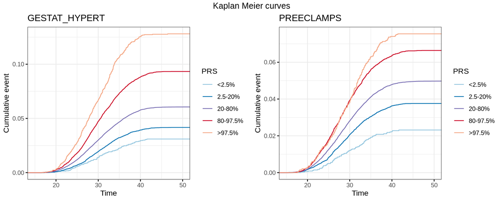

KM curves

```r
 ep=names_ep[[1]]   #Tämän alustuksen tarve on kyllä ihme juttu. Suoritus kaatuu ilman sitä.

  plot_list <- lapply(names_ep, function(ep){
    my_ggkmplot(kms[[ep]], str_glue("{ep}"), my_labels, xlim=c(15,50))
  })
  plots <- arrange_ggsurvplots(plot_list, nrow = 1, ncol = 2,  title = "Kaplan Meier curves", print=F)
  ggsave(file = str_glue("{fig_path}/km.prs.preg.png"), plot = plots, height = 4, width = 10, dpi = 150)
```

### 2.1.2 KM: Pre-eclampsia PRS

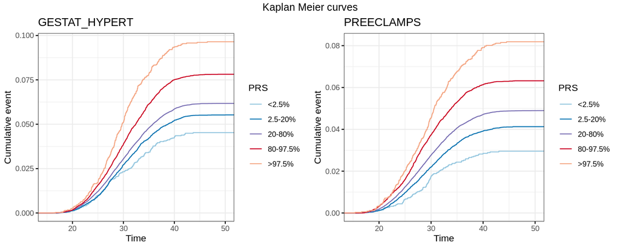

KM curves

```r
 ep=names_ep[[1]]   #Tämän alustuksen tarve on kyllä ihme juttu. Suoritus kaatuu ilman sitä.

  plot_list.prec <- lapply(names_ep, function(ep){
    my_ggkmplot(kms.prec[[ep]], str_glue("{ep}"), my_labels, xlim=c(15,50))
  })
  plots.prec <- arrange_ggsurvplots(plot_list.prec, nrow = 1, ncol = 2,  title = "Kaplan Meier curves", print=F)
  ggsave(file = str_glue("{fig_path}/km.prec.prs.preg.png"), plot = plots.prec,height = 4, width = 10, dpi = 150)
```

### 2.1.3 log log: SBP PRS

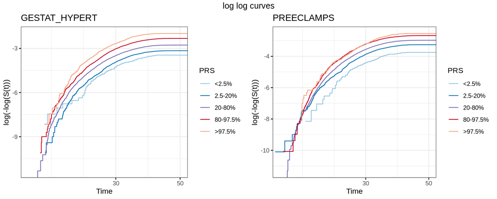

log log curves

```r
 ep=names_ep[[1]]   #Tämän alustuksen tarve on kyllä ihme juttu. Suoritus kaatuu ilman sitä.

  plot_list <- lapply(names_ep, function(ep){
    my_ggkmplot(kms[[ep]], str_glue("{ep}"), my_labels, xlim=c(15,50), fun="cloglog")
  })
  plots <- arrange_ggsurvplots(plot_list, nrow = 1, ncol = 2, title = "log log curves", print=F)
  ggsave(file = str_glue("{fig_path}/log.prs.preg.png"), plot = plots, height = 4, width = 10, dpi = 150)
```

### 2.1.4 log log: Pre-eclampsia PRS

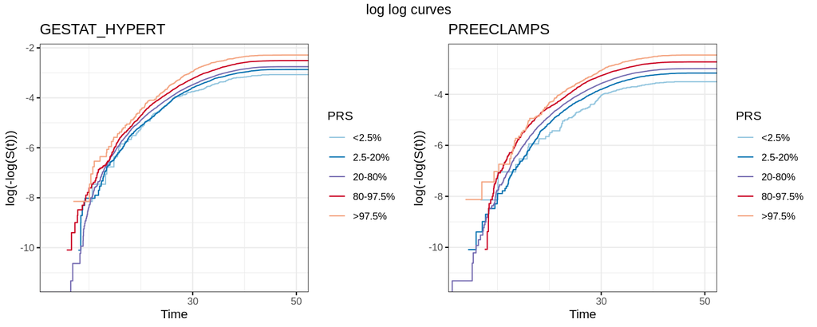

log log curves

```r
 ep=names_ep[[1]]   #Tämän alustuksen tarve on kyllä ihme juttu. Suoritus kaatuu ilman sitä.

  plot_list.prec <- lapply(names_ep, function(ep){
    my_ggkmplot(kms.prec[[ep]], str_glue("{ep}"), my_labels, xlim=c(15,50), fun="cloglog")
  })
  plots.prec <- arrange_ggsurvplots(plot_list.prec, nrow = 1, ncol = 2, title = "log log curves", print=F)
  ggsave(file = str_glue("{fig_path}/log.prec.prs.preg.png"), plot = plots.prec, height = 4, width = 10, dpi = 150)
```

log log curves are not straight lines, probably because propability of pregnancy changes over time. However for most curves the distance between curves stays about constant by time.

## 2.2 Cox model: Continuous score

We will use covariate adjusted Cox models to study associations between *continuous* SBP and preeclampsia PRS’s and different endpoints.

Covariates:

- Batch
- Data collection year
- Genetic PC1-PC10

### 2.2.1 SBP PRS

```r
gen_covs <- c("batch", "BL_YEAR","PC1", "PC2", "PC3", "PC4", "PC5", "PC6", "PC7", "PC8","PC9", "PC10")
gen_covs_f<- paste(gen_covs, collapse = " + ")

cxs.cs <-
    lapply(names_ep, function(ep){
      my_formula <- str_glue("Surv({ep}_AGE, {ep}) ~ SBP_SCALED + {gen_covs_f}")
      coxph(as.formula(my_formula), data=list.df.p[[ep]])
    }) %>% setNames(names_ep)

table.cxs.cs.sbp <-
  my_cxlist_to_hrtable2(cxs.cs, list.df.p, ep_title="Endpoint", select="SBP_")

table.cxs.cs.sbp %>%
    knitr::kable(digits=2) %>%
    kable_classic() %>%
    row_spec(0,bold=TRUE)
```

| Endpoint | HR (95% CI) | P-value | Cases | Controls |
| --- | --- | --- | --- | --- |
| GESTAT_HYPERT | 1.38 (1.35-1.41) | 8.8e-194 | 8488 | 129829 |
| PREECLAMPS | 1.26 (1.23-1.29) | 3.5e-78 | 6643 | 129711 |

### 2.2.2 Preeclampsia PRS

```r
cxs.cs.prec <-
    lapply(names_ep, function(ep){
      my_formula <- str_glue("Surv({ep}_AGE, {ep}) ~ PREC_SCALED + {gen_covs_f}")
      coxph(as.formula(my_formula), data=list.df.p[[ep]])
    }) %>% setNames(names_ep)


table.cxs.cs.prec <-
  my_cxlist_to_hrtable2(cxs.cs.prec, list.df.p, ep_title="Endpoint", select="PREC_")

table.cxs.cs.prec %>%
    knitr::kable(digits=2) %>%
    kable_classic() %>%
    row_spec(0,bold=TRUE)
```

| Endpoint | HR (95% CI) | P-value | Cases | Controls |
| --- | --- | --- | --- | --- |
| GESTAT_HYPERT | 1.16 (1.14-1.19) | 1.5e-44 | 8488 | 129829 |
| PREECLAMPS | 1.21 (1.18-1.24) | 1.2e-55 | 6643 | 129711 |

### 2.2.3 Significance: SBP PRS vs. preeclampsia PRS

**GTH**

```r
cx1 <- summary(cxs.cs$GESTAT_HYPERT)
cx2 <- summary(cxs.cs.prec$GESTAT_HYPERT)

x1    <- list.df.p$GESTAT_HYPERT$SBP_SCALED
beta1 <- cx1$coefficients["SBP_SCALED","coef"]
se1   <- cx1$coefficients["SBP_SCALED","se(coef)"]
x2    <- list.df.p$GESTAT_HYPERT$PREC_SCALED
beta2 <- cx2$coefficients["PREC_SCALED","coef"]
se2   <- cx2$coefficients["PREC_SCALED","se(coef)"]
n     <- cx2$n

hr.comp2(x1, beta1, se1, x2, beta2, se2, n)
```

```
## $p.value
## [1] 1.663725e-31
##
## $hr1
## [1] 1.382915
##
## $hr2
## [1] 1.164742
```

**Preeclampsia**

```r
cx1 <- summary(cxs.cs$PREECLAMPS)
cx2 <- summary(cxs.cs.prec$PREECLAMPS)

x1    <- list.df.p$PREECLAMPS$SBP_SCALED
beta1 <- cx1$coefficients["SBP_SCALED","coef"]
se1   <- cx1$coefficients["SBP_SCALED","se(coef)"]
x2    <- list.df.p$PREECLAMPS$PREC_SCALED
beta2 <- cx2$coefficients["PREC_SCALED","coef"]
se2   <- cx2$coefficients["PREC_SCALED","se(coef)"]
n     <- cx2$n

hr.comp2(x1, beta1, se1, x2, beta2, se2, n)
```

```
## $p.value
## [1] 0.01197746
##
## $hr1
## [1] 1.259621
##
## $hr2
## [1] 1.213063
```

### 2.2.4 Forest plots

```r
eps_to_forest <- c("PREECLAMPS", "GESTAT_HYPERT")
pretty_names_to_forest <- c(PREECLAMPS = "Preeclampsia", ECLAMPSIA = "Eclampsia", GESTAT_HYPERT = "Gestational\nHypertension")
order_forest <- c(PREECLAMPS = 1, ECLAMPSIA = 2, GESTAT_HYPERT = 3)

table_to_forest <-
  bind_rows(table.cxs.cs.sbp %>% mutate(prs = "BP PRS"),
          table.cxs.cs.prec %>% mutate(prs="Preeclampsia PRS")) %>%
  filter(Endpoint %in% eps_to_forest) %>%
  mutate(`HR (95% CI)` = str_replace(`HR (95% CI)`, "^(.+) .(.+-.+).$", "\\1-\\2")) %>%
  separate("HR (95% CI)", c("mean","lower","upper"), sep = "-") %>%
  mutate(nr = order_forest[Endpoint]) %>%
  mutate(Endpoint = pretty_names_to_forest[Endpoint]) %>%
  mutate(empty = "                             ") %>%
  arrange(nr) %>%
  select(empty,Endpoint, mean, lower, upper, prs)  %>%
  mutate_at(c("mean","lower","upper"), as.double)



forest <- table_to_forest %>%
  group_by(prs) %>%
  forestplot(labeltext = c(empty, Endpoint),
             graph.pos=2,
             clip = c(0.8,1.5),
             zero = 1,
             xlog = F,
             boxsize = 0.1,
             lty.ci = 1,
             lwd.ci = 1.8,
             ci.vertices = F,
             col = fpColors(box = c("#F8766D", "#00BFC4"),
                            line = c("#F8766D", "#00BFC4")),
             legend_args = fpLegend(pos = list(x = -0.45, y = 0.86)),
             txt_gp = fpTxtGp(legend=gpar(cex=1),
                              ticks=gpar(cex=1),
                              label=gpar(cex=1.1)),
             xticks = c(1, 1.2, 1.4),
             fn.ci_norm = list(list(fpDrawNormalCI, fpDrawCircleCI),
                               list(fpDrawNormalCI, fpDrawCircleCI))
  )

#c("#CA0020", "#0571B0")

pdf(file= str_glue("{fig_path}/graph_abs.pdf"), height = 2.5, width = 6)
   forest
dev.off()
```

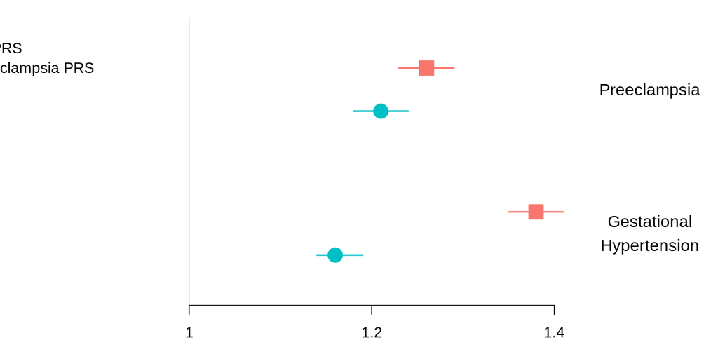

```r
forest
```

**All coefficients**

```r
lapply(cxs.cs, print)
```

```
## Call:
## coxph(formula = as.formula(my_formula), data = list.df.p[[ep]])
##
##                                                        coef  exp(coef)
## SBP_SCALED                                        3.242e-01  1.383e+00
## batchAxiomGT1_b02_V4                             -2.189e-01  8.034e-01
## batchAxiomGT1_b03_V4                             -1.259e-01  8.817e-01
## batchAxiomGT1_b04_V4                             -3.827e-01  6.820e-01
## batchAxiomGT1_b05_V4                             -4.927e-02  9.519e-01
## batchAxiomGT1_b06_V4                             -4.100e-01  6.637e-01
## batchAxiomGT1_b07_V4                             -1.646e-01  8.482e-01
## batchAxiomGT1_b08_V4                             -5.291e-02  9.485e-01
## batchAxiomGT1_b09_V4                              1.761e-01  1.193e+00
## batchAxiomGT1_b10_V4                              2.643e-02  1.027e+00
## batchAxiomGT1_b11_V4                             -5.738e-02  9.442e-01
## batchAxiomGT1_b12_V4                              1.215e-01  1.129e+00
## batchAxiomGT1_b13_V4                             -1.829e-01  8.328e-01
## batchAxiomGT1_b14_V4                             -1.830e-02  9.819e-01
## batchAxiomGT1_b15_V4                              1.492e-01  1.161e+00
## batchAxiomGT1_b16_V4                              7.661e-03  1.008e+00
## batchAxiomGT1_b17_V4                              1.716e-01  1.187e+00
## batchAxiomGT1_b18_V4                              2.313e-01  1.260e+00
## batchAxiomGT1_b19_V4                              3.151e-02  1.032e+00
## batchAxiomGT1_b20_V4                             -4.994e-01  6.069e-01
## batchAxiomGT1_b21_V4                              5.778e-02  1.059e+00
## batchAxiomGT1_b22_V4                             -2.711e-02  9.733e-01
## batchAxiomGT1_b23_V4                             -1.178e-02  9.883e-01
## batchAxiomGT1_b24_V4                              2.197e-01  1.246e+00
## batchAxiomGT1_b25_V4                              4.879e-02  1.050e+00
## batchAxiomGT1_b26_V2P2                           -9.987e-02  9.050e-01
## batchAxiomGT1_b27_V2P2                            3.427e-01  1.409e+00
## batchAxiomGT1_b28_V2P2                           -4.952e-02  9.517e-01
## batchAxiomGT1_b29_V2P2                           -4.260e-02  9.583e-01
## batchAxiomGT1_b30_V2P2                            1.971e-01  1.218e+00
## batchAxiomGT1_b31_V2                              1.323e-01  1.141e+00
## batchAxiomGT1_b3234_V2                            2.318e-02  1.023e+00
## batchAxiomGT1_b33_V2                             -1.749e-01  8.395e-01
## batchAxiomGT1_b35_V2                             -2.547e-01  7.752e-01
## batchAxiomGT1_b36_V2                              1.911e-02  1.019e+00
## batchAxiomGT1_b37_V2                              1.044e-01  1.110e+00
```

[output cut: 429 more lines]

```
## batchDS9_FINRISK_Mrpred_norm                      0.2438590 -1.079 0.280616
## BL_YEAR                                           0.0030036 -3.394 0.000689
## PC1                                               0.6786874  3.472 0.000516
## PC2                                               1.2239479  2.248 0.024601
## PC3                                               1.3703269  0.872 0.383034
## PC4                                               1.5312075 -2.554 0.010641
## PC5                                               1.7182546 -2.802 0.005074
## PC6                                               1.7051141 -0.343 0.731599
## PC7                                               2.0172896 -4.353 1.34e-05
## PC8                                               2.1656959  0.170 0.864653
## PC9                                               2.1680714 -0.575 0.565617
## PC10                                              2.3046806 -2.751 0.005935
##
## Likelihood ratio test=741.8  on 117 df, p=< 2.2e-16
## n= 136354, number of events= 6643
```

```
## $GESTAT_HYPERT
## Call:
## coxph(formula = as.formula(my_formula), data = list.df.p[[ep]])
##
##                                                        coef  exp(coef)
## SBP_SCALED                                        3.242e-01  1.383e+00
## batchAxiomGT1_b02_V4                             -2.189e-01  8.034e-01
## batchAxiomGT1_b03_V4                             -1.259e-01  8.817e-01
## batchAxiomGT1_b04_V4                             -3.827e-01  6.820e-01
## batchAxiomGT1_b05_V4                             -4.927e-02  9.519e-01
## batchAxiomGT1_b06_V4                             -4.100e-01  6.637e-01
## batchAxiomGT1_b07_V4                             -1.646e-01  8.482e-01
## batchAxiomGT1_b08_V4                             -5.291e-02  9.485e-01
## batchAxiomGT1_b09_V4                              1.761e-01  1.193e+00
## batchAxiomGT1_b10_V4                              2.643e-02  1.027e+00
## batchAxiomGT1_b11_V4                             -5.738e-02  9.442e-01
## batchAxiomGT1_b12_V4                              1.215e-01  1.129e+00
## batchAxiomGT1_b13_V4                             -1.829e-01  8.328e-01
## batchAxiomGT1_b14_V4                             -1.830e-02  9.819e-01
## batchAxiomGT1_b15_V4                              1.492e-01  1.161e+00
## batchAxiomGT1_b16_V4                              7.661e-03  1.008e+00
## batchAxiomGT1_b17_V4                              1.716e-01  1.187e+00
## batchAxiomGT1_b18_V4                              2.313e-01  1.260e+00
## batchAxiomGT1_b19_V4                              3.151e-02  1.032e+00
## batchAxiomGT1_b20_V4                             -4.994e-01  6.069e-01
## batchAxiomGT1_b21_V4                              5.778e-02  1.059e+00
## batchAxiomGT1_b22_V4                             -2.711e-02  9.733e-01
## batchAxiomGT1_b23_V4                             -1.178e-02  9.883e-01
## batchAxiomGT1_b24_V4                              2.197e-01  1.246e+00
## batchAxiomGT1_b25_V4                              4.879e-02  1.050e+00
## batchAxiomGT1_b26_V2P2                           -9.987e-02  9.050e-01
## batchAxiomGT1_b27_V2P2                            3.427e-01  1.409e+00
## batchAxiomGT1_b28_V2P2                           -4.952e-02  9.517e-01
## batchAxiomGT1_b29_V2P2                           -4.260e-02  9.583e-01
## batchAxiomGT1_b30_V2P2                            1.971e-01  1.218e+00
## batchAxiomGT1_b31_V2                              1.323e-01  1.141e+00
## batchAxiomGT1_b3234_V2                            2.318e-02  1.023e+00
## batchAxiomGT1_b33_V2                             -1.749e-01  8.395e-01
## batchAxiomGT1_b35_V2                             -2.547e-01  7.752e-01
## batchAxiomGT1_b36_V2                              1.911e-02  1.019e+00
```

[output cut: 432 more lines]

```
## batchDS9_FINRISK_Mrpred_norm                      0.2438590 -1.079 0.280616
## BL_YEAR                                           0.0030036 -3.394 0.000689
## PC1                                               0.6786874  3.472 0.000516
## PC2                                               1.2239479  2.248 0.024601
## PC3                                               1.3703269  0.872 0.383034
## PC4                                               1.5312075 -2.554 0.010641
## PC5                                               1.7182546 -2.802 0.005074
## PC6                                               1.7051141 -0.343 0.731599
## PC7                                               2.0172896 -4.353 1.34e-05
## PC8                                               2.1656959  0.170 0.864653
## PC9                                               2.1680714 -0.575 0.565617
## PC10                                              2.3046806 -2.751 0.005935
##
## Likelihood ratio test=741.8  on 117 df, p=< 2.2e-16
## n= 136354, number of events= 6643
```

```r
lapply(cxs.cs.prec, print)
```

```
## Call:
## coxph(formula = as.formula(my_formula), data = list.df.p[[ep]])
##
##                                                        coef  exp(coef)
## PREC_SCALED                                       1.525e-01  1.165e+00
## batchAxiomGT1_b02_V4                             -2.239e-01  7.994e-01
## batchAxiomGT1_b03_V4                             -1.638e-01  8.489e-01
## batchAxiomGT1_b04_V4                             -4.051e-01  6.669e-01
## batchAxiomGT1_b05_V4                             -9.129e-02  9.128e-01
## batchAxiomGT1_b06_V4                             -4.369e-01  6.461e-01
## batchAxiomGT1_b07_V4                             -1.846e-01  8.315e-01
## batchAxiomGT1_b08_V4                             -7.469e-02  9.280e-01
## batchAxiomGT1_b09_V4                              1.561e-01  1.169e+00
## batchAxiomGT1_b10_V4                              3.464e-04  1.000e+00
## batchAxiomGT1_b11_V4                             -8.370e-02  9.197e-01
## batchAxiomGT1_b12_V4                              9.317e-02  1.098e+00
## batchAxiomGT1_b13_V4                             -2.071e-01  8.129e-01
## batchAxiomGT1_b14_V4                             -4.349e-02  9.574e-01
## batchAxiomGT1_b15_V4                              1.375e-01  1.147e+00
## batchAxiomGT1_b16_V4                             -1.267e-02  9.874e-01
## batchAxiomGT1_b17_V4                              1.528e-01  1.165e+00
## batchAxiomGT1_b18_V4                              2.101e-01  1.234e+00
## batchAxiomGT1_b19_V4                             -1.185e-02  9.882e-01
## batchAxiomGT1_b20_V4                             -5.185e-01  5.954e-01
## batchAxiomGT1_b21_V4                              3.259e-02  1.033e+00
## batchAxiomGT1_b22_V4                             -4.655e-02  9.545e-01
## batchAxiomGT1_b23_V4                             -3.715e-02  9.635e-01
## batchAxiomGT1_b24_V4                              2.091e-01  1.233e+00
## batchAxiomGT1_b25_V4                              2.028e-02  1.020e+00
## batchAxiomGT1_b26_V2P2                           -1.210e-01  8.860e-01
## batchAxiomGT1_b27_V2P2                            3.151e-01  1.370e+00
## batchAxiomGT1_b28_V2P2                           -6.273e-02  9.392e-01
## batchAxiomGT1_b29_V2P2                           -4.799e-02  9.531e-01
## batchAxiomGT1_b30_V2P2                            1.778e-01  1.195e+00
## batchAxiomGT1_b31_V2                              1.043e-01  1.110e+00
## batchAxiomGT1_b3234_V2                            1.614e-02  1.016e+00
## batchAxiomGT1_b33_V2                             -1.969e-01  8.213e-01
## batchAxiomGT1_b35_V2                             -2.697e-01  7.636e-01
## batchAxiomGT1_b36_V2                             -1.154e-02  9.885e-01
## batchAxiomGT1_b37_V2                              8.940e-02  1.094e+00
```

[output cut: 429 more lines]

```
## batchDS9_FINRISK_Mrpred_norm                      0.2438350 -1.174 0.240438
## BL_YEAR                                           0.0030016 -3.374 0.000741
## PC1                                               0.6768797  4.228 2.36e-05
## PC2                                               1.2235273  1.863 0.062489
## PC3                                               1.3708265  0.660 0.509225
## PC4                                               1.5265588 -2.800 0.005105
## PC5                                               1.7217799 -2.727 0.006394
## PC6                                               1.7003581 -0.385 0.700128
## PC7                                               2.0144472 -4.290 1.78e-05
## PC8                                               2.1663157 -0.203 0.839505
## PC9                                               2.1735683 -0.301 0.763597
## PC10                                              2.3059472 -2.330 0.019822
##
## Likelihood ratio test=638.2  on 117 df, p=< 2.2e-16
## n= 136354, number of events= 6643
```

```
## $GESTAT_HYPERT
## Call:
## coxph(formula = as.formula(my_formula), data = list.df.p[[ep]])
##
##                                                        coef  exp(coef)
## PREC_SCALED                                       1.525e-01  1.165e+00
## batchAxiomGT1_b02_V4                             -2.239e-01  7.994e-01
## batchAxiomGT1_b03_V4                             -1.638e-01  8.489e-01
## batchAxiomGT1_b04_V4                             -4.051e-01  6.669e-01
## batchAxiomGT1_b05_V4                             -9.129e-02  9.128e-01
## batchAxiomGT1_b06_V4                             -4.369e-01  6.461e-01
## batchAxiomGT1_b07_V4                             -1.846e-01  8.315e-01
## batchAxiomGT1_b08_V4                             -7.469e-02  9.280e-01
## batchAxiomGT1_b09_V4                              1.561e-01  1.169e+00
## batchAxiomGT1_b10_V4                              3.464e-04  1.000e+00
## batchAxiomGT1_b11_V4                             -8.370e-02  9.197e-01
## batchAxiomGT1_b12_V4                              9.317e-02  1.098e+00
## batchAxiomGT1_b13_V4                             -2.071e-01  8.129e-01
## batchAxiomGT1_b14_V4                             -4.349e-02  9.574e-01
## batchAxiomGT1_b15_V4                              1.375e-01  1.147e+00
## batchAxiomGT1_b16_V4                             -1.267e-02  9.874e-01
## batchAxiomGT1_b17_V4                              1.528e-01  1.165e+00
## batchAxiomGT1_b18_V4                              2.101e-01  1.234e+00
## batchAxiomGT1_b19_V4                             -1.185e-02  9.882e-01
## batchAxiomGT1_b20_V4                             -5.185e-01  5.954e-01
## batchAxiomGT1_b21_V4                              3.259e-02  1.033e+00
## batchAxiomGT1_b22_V4                             -4.655e-02  9.545e-01
## batchAxiomGT1_b23_V4                             -3.715e-02  9.635e-01
## batchAxiomGT1_b24_V4                              2.091e-01  1.233e+00
## batchAxiomGT1_b25_V4                              2.028e-02  1.020e+00
## batchAxiomGT1_b26_V2P2                           -1.210e-01  8.860e-01
## batchAxiomGT1_b27_V2P2                            3.151e-01  1.370e+00
## batchAxiomGT1_b28_V2P2                           -6.273e-02  9.392e-01
## batchAxiomGT1_b29_V2P2                           -4.799e-02  9.531e-01
## batchAxiomGT1_b30_V2P2                            1.778e-01  1.195e+00
## batchAxiomGT1_b31_V2                              1.043e-01  1.110e+00
## batchAxiomGT1_b3234_V2                            1.614e-02  1.016e+00
## batchAxiomGT1_b33_V2                             -1.969e-01  8.213e-01
## batchAxiomGT1_b35_V2                             -2.697e-01  7.636e-01
## batchAxiomGT1_b36_V2                             -1.154e-02  9.885e-01
```

[output cut: 432 more lines]

```
## batchDS9_FINRISK_Mrpred_norm                      0.2438350 -1.174 0.240438
## BL_YEAR                                           0.0030016 -3.374 0.000741
## PC1                                               0.6768797  4.228 2.36e-05
## PC2                                               1.2235273  1.863 0.062489
## PC3                                               1.3708265  0.660 0.509225
## PC4                                               1.5265588 -2.800 0.005105
## PC5                                               1.7217799 -2.727 0.006394
## PC6                                               1.7003581 -0.385 0.700128
## PC7                                               2.0144472 -4.290 1.78e-05
## PC8                                               2.1663157 -0.203 0.839505
## PC9                                               2.1735683 -0.301 0.763597
## PC10                                              2.3059472 -2.330 0.019822
##
## Likelihood ratio test=638.2  on 117 df, p=< 2.2e-16
## n= 136354, number of events= 6643
```

**Proportional hazard assumption**

Schoenfeld residuals against the transformed time:

```r
lapply(names_ep, function(ep){
    tryCatch(cox.zph(cxs.cs[[ep]]), error=function(e) NULL)
}) %>% setNames(names_ep)
```

```
## $GESTAT_HYPERT
##              chisq  df       p
## SBP_SCALED   3.974   1 0.04621
## batch      152.821 105 0.00161
## BL_YEAR      5.426   1 0.01984
## PC1         20.587   1 5.7e-06
## PC2          1.387   1 0.23897
## PC3          3.054   1 0.08055
## PC4         11.613   1 0.00066
## PC5          2.766   1 0.09631
## PC6          2.369   1 0.12376
## PC7          1.155   1 0.28258
## PC8          0.686   1 0.40763
## PC9          0.999   1 0.31763
## PC10         1.359   1 0.24375
## GLOBAL     186.398 117 4.7e-05
##
## $PREECLAMPS
##               chisq  df       p
## SBP_SCALED 1.18e+00   1  0.2774
## batch      1.36e+02 105  0.0213
## BL_YEAR    5.26e+00   1  0.0219
## PC1        7.88e-01   1  0.3746
## PC2        6.03e-01   1  0.4375
## PC3        3.11e-03   1  0.9556
## PC4        1.63e+01   1 5.5e-05
## PC5        1.88e-01   1  0.6648
## PC6        3.64e-05   1  0.9952
## PC7        1.57e+00   1  0.2103
## PC8        2.15e-01   1  0.6426
## PC9        4.29e-02   1  0.8359
## PC10       3.81e+00   1  0.0510
## GLOBAL     1.61e+02 117  0.0046
```

```r
lapply(names_ep, function(ep){
    tryCatch(cox.zph(cxs.cs.prec[[ep]]), error=function(e) NULL)
}) %>% setNames(names_ep)
```

```
## $GESTAT_HYPERT
##               chisq  df       p
## PREC_SCALED   0.442   1 0.50613
## batch       152.765 105 0.00163
## BL_YEAR       5.458   1 0.01947
## PC1          20.762   1 5.2e-06
## PC2           1.416   1 0.23412
## PC3           3.083   1 0.07912
## PC4          11.510   1 0.00069
## PC5           2.797   1 0.09445
## PC6           2.396   1 0.12168
## PC7           1.175   1 0.27844
## PC8           0.693   1 0.40505
## PC9           1.014   1 0.31392
## PC10          1.367   1 0.24233
## GLOBAL      184.255 117 7.3e-05
##
## $PREECLAMPS
##                chisq  df      p
## PREC_SCALED 4.47e+00   1 0.0344
## batch       1.36e+02 105 0.0217
## BL_YEAR     5.29e+00   1 0.0215
## PC1         8.02e-01   1 0.3704
## PC2         6.06e-01   1 0.4361
## PC3         3.06e-03   1 0.9559
## PC4         1.61e+01   1  6e-05
## PC5         1.95e-01   1 0.6586
## PC6         9.36e-07   1 0.9992
## PC7         1.56e+00   1 0.2112
## PC8         2.09e-01   1 0.6475
## PC9         4.30e-02   1 0.8358
## PC10        3.80e+00   1 0.0514
## GLOBAL      1.64e+02 117 0.0028
```

## 2.3 Cox model: Categorized score

We will use covariate adjusted Cox models to study associations between SBP PRS score *categories* and different endpoints. Endpoints with significant results from previous model are selected.

Covariates:

- Batch
- Data collection year
- Genetic PC1-PC10

### 2.3.1 HR table

#### 2.3.1.1 SPB PRS

```r
names_ep <- list("GESTAT_HYPERT", "PREECLAMPS")
pretty_names_ep <- list(GESTAT_HYPERT = "Gestational Hypertension", PREECLAMPS = "Preeclampsia")


#Change reference
list.dfr.p.nona <- lapply(names_ep, function(ep){
    list.df.p[[ep]] %>%
       mutate(SBP_CAT= relevel(SBP_CAT, ref = "20-80%"),
              PREC_CAT= relevel(PREC_CAT, ref = "20-80%"))
  }) %>% setNames(names_ep)

#dfr.p <- df.p %>%
 # mutate(SBP_CAT= relevel(SBP_CAT, ref = "20-80%"),
  #       PREC_CAT= relevel(PREC_CAT, ref = "20-80%"))

cxs <-
    lapply(names_ep, function(ep){
      my_formula <- str_glue("Surv({ep}_AGE, {ep}) ~ SBP_CAT + {gen_covs_f}")
      coxph(as.formula(my_formula), data=list.dfr.p.nona[[ep]])
    }) %>% setNames(names_ep)

lapply(cxs, royston)
```

```
## $GESTAT_HYPERT
##          D      se(D)        R.D       R.PM
## 0.64930499 0.01733742 0.09144502 0.09205132
##
## $PREECLAMPS
##          D      se(D)        R.D       R.PM
## 0.51100708 0.01959783 0.05868158 0.06281619
```

```r
lapply(names_ep, function(ep){

    cat_name <- "SBP_CAT"

      tmp <- my_extr_coef(cxs[[ep]], select= cat_name, title=ep) %>%
      mutate(names = str_remove(names, cat_name))

    extract_ns2(ep, cat_name, list.df.p[[ep]]) %>%
      left_join(tmp, by = c("quantile" = "names")) %>%
      my_tidy_table() %>%
      select(quantile, cases, controls, est, pval) %>%
      add_row(quantile="", cases=NA, controls=NA, est="", pval=NA, .before=1)

  }) %>%
  bind_rows() %>%
  rename(PRS=quantile, `HR (95% CI)` = est, `P-value` = pval, Cases=cases, Controls=controls) %>%
  mutate_all(as.character) %>%
  mutate_all(replace_na,"") %>%
  knitr::kable(digits=2) %>%
  kable_classic() %>%
  pack_rows(pretty_names_ep[[1]],1, 6) %>%
  pack_rows(pretty_names_ep[[2]],7, 12) %>%
  #pack_rows(pretty_names_ep[[3]],13, 18) %>%
  #pack_rows(pretty_names_ep[[4]],19, 24) %>%
  row_spec(0,bold=TRUE)
```

PRS

Cases

Controls

HR (95% CI)

P-value

**Gestational Hypertension**

<2.5%

103

3369

0.51 (0.42-0.62)

1.7e-11

2.5-20%

974

23418

0.69 (0.64-0.74)

1.2e-26

20-80%

4815

77990

80-97.5%

2169

22034

1.55 (1.47-1.63)

3.4e-64

>97.5%

427

3018

2.17 (1.96-2.39)

7.8e-53

**Preeclampsia**

<2.5%

77

3368

0.46 (0.37-0.57)

1.3e-11

2.5-20%

878

23344

0.75 (0.7-0.81)

2.2e-14

20-80%

3928

77819

80-97.5%

1518

22110

1.34 (1.27-1.43)

1.7e-22

>97.5%

242

3070

1.53 (1.35-1.74)

1.3e-10

#### 2.3.1.2 Preeclampsia PRS

```r
cxs.prec <-
    lapply(names_ep, function(ep){
      my_formula <- str_glue("Surv({ep}_AGE, {ep}) ~ PREC_CAT + {gen_covs_f}")
      coxph(as.formula(my_formula), data=list.dfr.p.nona[[ep]])
    }) %>% setNames(names_ep)

lapply(cxs.prec, royston)
```

```
## $GESTAT_HYPERT
##          D      se(D)        R.D       R.PM
## 0.49389141 0.01730129 0.05502914 0.05786016
##
## $PREECLAMPS
##          D      se(D)        R.D       R.PM
## 0.47625556 0.01958752 0.05136762 0.05270362
```

```r
lapply(names_ep, function(ep){

    cat_name <- "PREC_CAT"

      tmp <- my_extr_coef(cxs.prec[[ep]], select= cat_name, title=ep) %>%
      mutate(names = str_remove(names, cat_name))

    extract_ns2(ep, cat_name, list.df.p[[ep]]) %>%
      left_join(tmp, by = c("quantile" = "names")) %>%
      my_tidy_table() %>%
      select(quantile, cases, controls, est, pval) %>%
      add_row(quantile="", cases=NA, controls=NA, est="", pval=NA, .before=1)

  }) %>%
  bind_rows() %>%
  rename(PRS=quantile, `HR (95% CI)` = est, `P-value` = pval, Cases=cases, Controls=controls) %>%
  mutate_all(as.character) %>%
  mutate_all(replace_na,"") %>%
  knitr::kable(digits=2) %>%
  kable_classic() %>%
  pack_rows(pretty_names_ep[[1]],1, 6) %>%
  pack_rows(pretty_names_ep[[2]],7, 12) %>%
  #pack_rows(pretty_names_ep[[3]],13, 18) %>%
  #pack_rows(pretty_names_ep[[4]],19, 24) %>%
  row_spec(0,bold=TRUE)
```

PRS

Cases

Controls

HR (95% CI)

P-value

**Gestational Hypertension**

<2.5%

151

3319

0.75 (0.64-0.88)

0.00042

2.5-20%

1288

23026

0.9 (0.85-0.96)

0.00064

20-80%

4913

78031

80-97.5%

1814

22323

1.26 (1.2-1.33)

1.3e-17

>97.5%

322

3130

1.58 (1.41-1.77)

1.4e-15

**Preeclampsia**

<2.5%

98

3335

0.6 (0.49-0.74)

7.7e-07

2.5-20%

954

23049

0.84 (0.78-0.9)

9.2e-07

20-80%

3867

77900

80-97.5%

1456

22311

1.3 (1.22-1.38)

2.1e-17

>97.5%

268

3116

1.68 (1.49-1.9)

2e-16

### 2.3.2 Cox-plots

**Choosing covariate values for the plot**

We used *mean* values for all numeric variables. For ‘batch’, we use the level with *lowest significance*. Let us look the lowest significance from a couple of example cases:

```r
cx.test <- cxs$GESTAT_HYPERT

summary(cx.test)$coefficients %>%
  as.data.frame() %>%
  mutate(name = row.names(.)) %>%
  rename(pval="Pr(>|z|)") %>%
  select("name", "coef", "exp(coef)","se(coef)", "pval") %>%
  arrange(pval) %>%
  tail(30)
```

|  | name | coef | exp(coef) | se(coef) | pval |
| --- | --- | --- | --- | --- | --- |
| batchAxiomGT1_b11_V4 | batchAxiomGT1_b11_V4 | -0.058806079 | 0.9428896 | 0.1518101 | 0.6984853 |
| batchAxiomGT1_b08_V4 | batchAxiomGT1_b08_V4 | -0.056227262 | 0.9453243 | 0.1468869 | 0.7018734 |
| batchAxiomGT1_b38_V2 | batchAxiomGT1_b38_V2 | 0.050103474 | 1.0513799 | 0.1467978 | 0.7328706 |
| batchDS2_BOTNIA_T2dgo_norm | batchDS2_BOTNIA_T2dgo_norm | -0.198549973 | 0.8199188 | 0.5881959 | 0.7356966 |
| batchAxiomGT1_b21_V4 | batchAxiomGT1_b21_V4 | 0.050766988 | 1.0520777 | 0.1513957 | 0.7373789 |
| batchAxiomGT1_b28_V2P2 | batchAxiomGT1_b28_V2P2 | -0.050898330 | 0.9503753 | 0.1544292 | 0.7417097 |
| batchAxiomGT1_b25_V4 | batchAxiomGT1_b25_V4 | 0.046681189 | 1.0477879 | 0.1467615 | 0.7504280 |
| batchAxiomGT1_b66_V5 | batchAxiomGT1_b66_V5 | -0.057352333 | 0.9442613 | 0.1864857 | 0.7584302 |
| batchAxiomGT1_b64_V3 | batchAxiomGT1_b64_V3 | 0.044759094 | 1.0457759 | 0.1492216 | 0.7642149 |
| batchAxiomGT1_b05_V4 | batchAxiomGT1_b05_V4 | -0.046706372 | 0.9543676 | 0.1570511 | 0.7661641 |

[output cut: 20 more lines]

```r
cx.test <- cxs$PREECLAMPS

summary(cx.test)$coefficients %>%
  as.data.frame() %>%
  mutate(name = row.names(.)) %>%
  rename(pval="Pr(>|z|)") %>%
  select("name", "coef", "exp(coef)","se(coef)", "pval") %>%
  arrange(pval) %>%
  tail(30)
```

|  | name | coef | exp(coef) | se(coef) | pval |
| --- | --- | --- | --- | --- | --- |
| batchDS17_H2000_Genmets_norm | batchDS17_H2000_Genmets_norm | -0.26939262 | 0.7638433 | 0.2597444 | 0.2996682 |
| batchAxiomGT1_b56_V3 | batchAxiomGT1_b56_V3 | 0.38838392 | 1.4745958 | 0.4039851 | 0.3363602 |
| batchAxiomGT1_b25_V4 | batchAxiomGT1_b25_V4 | 0.18021368 | 1.1974732 | 0.1878275 | 0.3373253 |
| batchAxiomGT1_b80_V5 | batchAxiomGT1_b80_V5 | 0.17686044 | 1.1934645 | 0.1910702 | 0.3546380 |
| batchDS10_FINRISK_Palotie_norm | batchDS10_FINRISK_Palotie_norm | -0.18048470 | 0.8348655 | 0.2004097 | 0.3678123 |
| batchDS13_FINRISK_Bf_norm | batchDS13_FINRISK_Bf_norm | 0.26188876 | 1.2993820 | 0.2932839 | 0.3718823 |
| batchAxiomGT1_b08_V4 | batchAxiomGT1_b08_V4 | 0.16067664 | 1.1743052 | 0.1825952 | 0.3788806 |
| PC3 | PC3 | 1.19044683 | 3.2885503 | 1.3702900 | 0.3849809 |
| batchAxiomGT1_b44_V2 | batchAxiomGT1_b44_V2 | 0.16294766 | 1.1769751 | 0.1895965 | 0.3900953 |
| batchAxiomGT1_b36_V2 | batchAxiomGT1_b36_V2 | 0.17194799 | 1.1876161 | 0.2001803 | 0.3903596 |

[output cut: 20 more lines]

**SBP PRS**

```r
#Covariate combinations
exp.tmp.covs <-  my_expand_covs(df.p, batch = "AxiomGT1_b77_V5")
exp.tmp.vars <- expand.grid(SBP_CAT = levels(df.p[["SBP_CAT"]]))
exp.cxs <- bind_cols(exp.tmp.vars, exp.tmp.covs)


fit.cxs <-
  lapply(names_ep, function(ep){
        survfit(cxs[[ep]], newdata = exp.cxs)
  }) %>% setNames(names_ep)



#Created without loop, because there are so many exceptions with these...

ep = "GESTAT_HYPERT"
p1 <- my_ggcoxplot(fit.cxs[[ep]], exp.cxs, title=pretty_names_ep[[ep]], labels=my_labels,
                   ylim=c(0,0.13), conf.int=F, legend="none", xlab="", ylab="Cumulative incidence")[["plot"]]

ep = "PREECLAMPS"
p2 <- my_ggcoxplot(fit.cxs[[ep]], exp.cxs, title=pretty_names_ep[[ep]], labels=my_labels,
                   ylim=c(0,0.13), conf.int=F, legend="none", xlab="Years", ylab="Cumulative incidence")[["plot"]]


plot_htprs <- grid.arrange(p1,p2,ncol = 1, top = text_grob("\n           BP PRS\n", size=15, face="bold", lineheight = 0.5))
```

**Preeclampsia PRS**

```r
#Covariate combinations

exp.tmp.vars.prec <- expand.grid(PREC_CAT = levels(df.p[["PREC_CAT"]]))
exp.cxs.prec <- bind_cols(exp.tmp.vars.prec, exp.tmp.covs)


fit.cxs.prec <-
  lapply(names_ep, function(ep){
        survfit(cxs.prec[[ep]], newdata = exp.cxs.prec)
  }) %>% setNames(names_ep)




#Created without loop, because there are so many exceptions with these...

ep = "GESTAT_HYPERT"
p1.p <- my_ggcoxplot(fit.cxs.prec[[ep]], exp.cxs.prec, title="", labels=my_labels,
                   ylim=c(0,0.13), conf.int=F, legend="none", xlab="", ylab="", legend.title="PRS")[["plot"]] +
  theme(legend.position = c(0.2,0.62)) +
  guides(col = guide_legend(reverse = TRUE))
  #  scale_linetype_manual(guide = guide_legend(reverse = TRUE))

# guides(col = guide_legend(reverse = TRUE))

ep = "PREECLAMPS"
p2.p <- my_ggcoxplot(fit.cxs.prec[[ep]], exp.cxs.prec, title="", labels=my_labels,
                   ylim=c(0,0.13), conf.int=F, legend="none", xlab="Years", ylab="")[["plot"]]


plot_preclprs <- grid.arrange(p1.p,p2.p, ncol = 1, top = text_grob("\n          Preeclampsia PRS\n", size=15, face="bold", lineheight = 0.5))
```

**Combined plot**

```r
plot_prs <- grid.arrange(plot_htprs, plot_preclprs, ncol = 2)
```

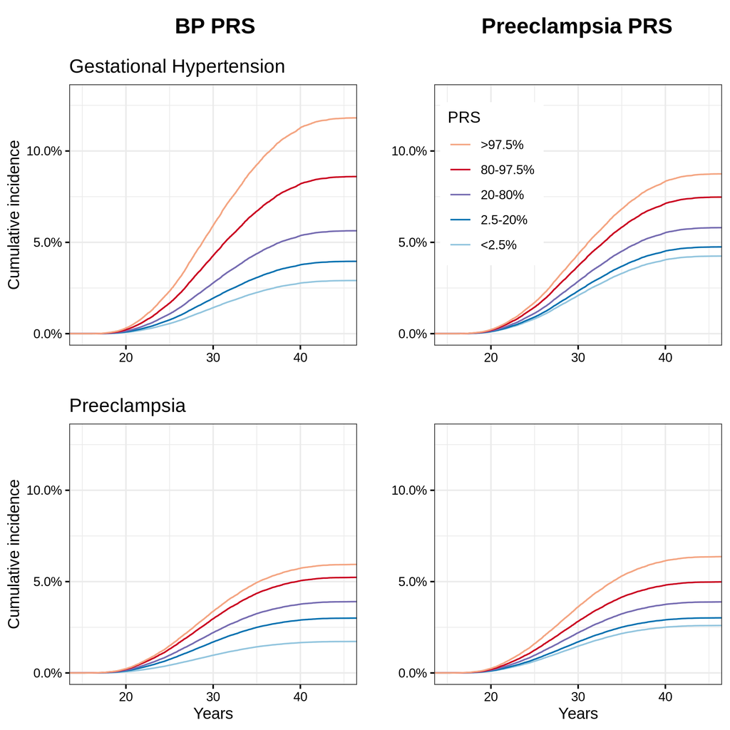

**Cox plots**

```r
ggsave(file = str_glue("{fig_path}/cx.both.prs.preg.png"), plot = plot_prs, height = 7, width = 7, dpi = 300)
ggsave(file = str_glue("{fig_path}/cx.both.prs.preg.eps"), plot = plot_prs, device = cairo_ps, height = 7, width = 7, dpi = 300)
```

## 2.4 C-statistics for pre-eclampsia

### 2.4.1 Models

**Model 1: base model**

```r
df.p2 <- list.df.p$PREECLAMPS %>%
  filter(!is.na(INDEX_AGE))

clin_covs_f<- paste(clin_covs, collapse = " + ")

my_formula1 <- as.formula(str_glue("PREECLAMPS ~ {clin_covs_f}"))
glm1 <- glm(my_formula1, data=df.p2, family=binomial())
glm1
```

```
##
## Call:  glm(formula = my_formula1, family = binomial(), data = df.p2)
##
## Coefficients:
##      (Intercept)         INDEX_AGE         IS_MULTIP            IS_IVF
##         -4.67763           0.05614           1.19457          -0.41052
##      HYPTENS_PRE       OBESITY_PRE  DIABETES_ALL_PRE       RENFAIL_PRE
##          1.53423           0.57125           0.97555           0.15427
##
## Degrees of Freedom: 136353 Total (i.e. Null);  136346 Residual
## Null Deviance:       53100
## Residual Deviance: 51110     AIC: 51130
```

```r
#Veall and Zimmermann concluded that from a set of six widely used measures the measure suggested by McKelvey and Zavoina had the closest correspondance to ordinary least square R2. The Aldrich-Nelson pseudo-R2 with the Veall-Zimmermann correction is the best approximation of the McKelvey-Zavoina pseudo-R2. Efron, Aldrich-Nelson, McFadden and Nagelkerke approaches severely underestimate the "true R2".

R2.1 <- PseudoR2(glm1, which="McKelveyZavoina")

glm1 %>%
  extract_glm_table() #%>%
```

| Variable | Odds | P-value |
| --- | --- | --- |
| INDEX_AGE | 1.06 (1.05-1.06) | 7.9e-125 |
| IS_MULTIP | 3.3 (2.89-3.76) | 3.0e-71 |
| IS_IVF | 0.66 (0.34-1.18) | 2.0e-01 |
| HYPTENS_PRE | 4.64 (3.85-5.57) | 1.7e-59 |
| OBESITY_PRE | 1.77 (1.47-2.11) | 5.0e-10 |
| DIABETES_ALL_PRE | 2.65 (2.45-2.87) | 3.0e-125 |
| RENFAIL_PRE | 1.17 (0.48-2.56) | 7.2e-01 |

```r
#  knitr::kable() %>%
#  kable_classic() %>%
#  row_spec(0,bold=TRUE)
```

**Model 2: pre-eclampsia PRS + covariates**

```r
#vars_for_table <- "_SCALED|PREG|HYP|OBES|DIAB|RENF"

my_formula2 <- as.formula(str_glue("PREECLAMPS ~ PREC_SCALED + {clin_covs_f}"))
glm2 <- glm(my_formula2, data=df.p2, family=binomial())
glm2
```

```
##
## Call:  glm(formula = my_formula2, family = binomial(), data = df.p2)
##
## Coefficients:
##      (Intercept)       PREC_SCALED         INDEX_AGE         IS_MULTIP
##         -4.70635           0.20118           0.05656           1.20067
##           IS_IVF       HYPTENS_PRE       OBESITY_PRE  DIABETES_ALL_PRE
##         -0.42215           1.51140           0.55597           0.97109
##      RENFAIL_PRE
##          0.15972
##
## Degrees of Freedom: 136353 Total (i.e. Null);  136345 Residual
## Null Deviance:       53100
## Residual Deviance: 50870     AIC: 50880
```

```r
R2.2 <- PseudoR2(glm2, which="McKelveyZavoina")

extract_glm_table(glm2) #%>%
```

| Variable | Odds | P-value |
| --- | --- | --- |
| PREC_SCALED | 1.22 (1.19-1.25) | 6.0e-56 |
| INDEX_AGE | 1.06 (1.05-1.06) | 1.8e-126 |
| IS_MULTIP | 3.32 (2.91-3.78) | 1.7e-71 |
| IS_IVF | 0.66 (0.33-1.17) | 1.8e-01 |
| HYPTENS_PRE | 4.53 (3.76-5.44) | 1.8e-57 |
| OBESITY_PRE | 1.74 (1.45-2.08) | 1.6e-09 |
| DIABETES_ALL_PRE | 2.64 (2.44-2.86) | 1.3e-123 |
| RENFAIL_PRE | 1.17 (0.48-2.59) | 7.1e-01 |

```r
#  knitr::kable() %>%
#  kable_classic() %>%
#  row_spec(0,bold=TRUE)
```

**Model 3: pre-eclampsia PRS + SBP PRS + covariates**

```r
my_formula3 <- as.formula(str_glue("PREECLAMPS ~ SBP_SCALED + PREC_SCALED + {clin_covs_f}"))
glm3 <- glm(my_formula3, data=df.p2, family=binomial())
glm3
```

```
##
## Call:  glm(formula = my_formula3, family = binomial(), data = df.p2)
##
## Coefficients:
##      (Intercept)        SBP_SCALED       PREC_SCALED         INDEX_AGE
##         -4.76519           0.22851           0.18284           0.05795
##        IS_MULTIP            IS_IVF       HYPTENS_PRE       OBESITY_PRE
##          1.21346          -0.45392           1.42298           0.55122
## DIABETES_ALL_PRE       RENFAIL_PRE
##          0.96848           0.24029
##
## Degrees of Freedom: 136353 Total (i.e. Null);  136344 Residual
## Null Deviance:       53100
## Residual Deviance: 50550     AIC: 50570
```

```r
R2.3 <- PseudoR2(glm3, which="McKelveyZavoina")

extract_glm_table(glm3) #%>%
```

| Variable | Odds | P-value |
| --- | --- | --- |
| SBP_SCALED | 1.26 (1.23-1.29) | 1.2e-70 |
| PREC_SCALED | 1.2 (1.17-1.23) | 4.1e-46 |
| INDEX_AGE | 1.06 (1.05-1.06) | 2.3e-132 |
| IS_MULTIP | 3.37 (2.94-3.83) | 1.4e-72 |
| IS_IVF | 0.64 (0.32-1.13) | 1.6e-01 |
| HYPTENS_PRE | 4.15 (3.44-4.99) | 8.1e-51 |
| OBESITY_PRE | 1.74 (1.44-2.07) | 2.5e-09 |
| DIABETES_ALL_PRE | 2.63 (2.43-2.85) | 1.5e-122 |
| RENFAIL_PRE | 1.27 (0.51-2.81) | 5.8e-01 |

```r
#  knitr::kable() %>%
#  kable_classic() %>%
#  row_spec(0,bold=TRUE)

R2 <- bind_rows(R2.1, R2.2, R2.3) %>%
  rename(PseudoR2 = McKelveyZavoina) %>%
  round(3)
```

**Test models: Only SBP PRS, Only PREC PRS, SBP PRS + clinical covariates**

```r
my_formula4 <- as.formula(str_glue("PREECLAMPS ~ SBP_SCALED"))
glm_onlysbp <- glm(my_formula4, data=df.p2, family=binomial())
print(glm_onlysbp)
```

```
##
## Call:  glm(formula = my_formula4, family = binomial(), data = df.p2)
##
## Coefficients:
## (Intercept)   SBP_SCALED
##      -2.995        0.239
##
## Degrees of Freedom: 136353 Total (i.e. Null);  136352 Residual
## Null Deviance:       53100
## Residual Deviance: 52740     AIC: 52750
```

```r
onlysbp <- extract_glm_table(glm_onlysbp)



my_formula5 <- as.formula(str_glue("PREECLAMPS ~ PREC_SCALED"))
glm_onlyprec <- glm(my_formula5, data=df.p2, family=binomial())
print(glm_onlyprec)
```

```
##
## Call:  glm(formula = my_formula5, family = binomial(), data = df.p2)
##
## Coefficients:
## (Intercept)  PREC_SCALED
##     -2.9893       0.2012
##
## Degrees of Freedom: 136353 Total (i.e. Null);  136352 Residual
## Null Deviance:       53100
## Residual Deviance: 52850     AIC: 52850
```

```r
onlyprec <- extract_glm_table(glm_onlyprec)

my_formula6 <- as.formula(str_glue("PREECLAMPS ~ SBP_SCALED + {clin_covs_f}"))
glm_sbpclin <- glm(my_formula6, data=df.p2, family=binomial())
print(glm_sbpclin)
```

```
##
## Call:  glm(formula = my_formula6, family = binomial(), data = df.p2)
##
## Coefficients:
##      (Intercept)        SBP_SCALED         INDEX_AGE         IS_MULTIP
##         -4.74250           0.24308           0.05763           1.20803
##           IS_IVF       HYPTENS_PRE       OBESITY_PRE  DIABETES_ALL_PRE
##         -0.44154           1.43819           0.56314           0.97273
##      RENFAIL_PRE
##          0.23948
##
## Degrees of Freedom: 136353 Total (i.e. Null);  136345 Residual
## Null Deviance:       53100
## Residual Deviance: 50750     AIC: 50770
```

```r
sbpclin <- extract_glm_table(glm_sbpclin)


my_formula7 <- as.formula(str_glue("PREECLAMPS ~ PREC_SCALED + {clin_covs_f}"))
glm_precclin <- glm(my_formula7, data=df.p2, family=binomial())
print(glm_precclin)
```

```
##
## Call:  glm(formula = my_formula7, family = binomial(), data = df.p2)
##
## Coefficients:
##      (Intercept)       PREC_SCALED         INDEX_AGE         IS_MULTIP
##         -4.70635           0.20118           0.05656           1.20067
##           IS_IVF       HYPTENS_PRE       OBESITY_PRE  DIABETES_ALL_PRE
##         -0.42215           1.51140           0.55597           0.97109
##      RENFAIL_PRE
##          0.15972
##
## Degrees of Freedom: 136353 Total (i.e. Null);  136345 Residual
## Null Deviance:       53100
## Residual Deviance: 50870     AIC: 50880
```

```r
precclin <- extract_glm_table(glm_precclin)

print(onlysbp)
```

```
##     Variable            Odds P-value
## 1 SBP_SCALED 1.27 (1.24-1.3) 9.6e-80
```

```r
print(sbpclin)
```

```
##           Variable             Odds  P-value
## 1       SBP_SCALED 1.28 (1.24-1.31)  2.0e-80
## 2        INDEX_AGE 1.06 (1.05-1.06) 3.5e-131
## 3        IS_MULTIP 3.35 (2.93-3.81)  2.5e-72
## 4           IS_IVF 0.64 (0.32-1.15)  1.7e-01
## 5      HYPTENS_PRE 4.21 (3.49-5.06)  3.7e-52
## 6      OBESITY_PRE  1.76 (1.46-2.1)  1.0e-09
## 7 DIABETES_ALL_PRE 2.65 (2.44-2.87) 4.9e-124
## 8      RENFAIL_PRE 1.27 (0.52-2.79)  5.7e-01
```

```r
print(onlyprec)
```

```
##      Variable             Odds P-value
## 1 PREC_SCALED 1.22 (1.19-1.25) 2.6e-57
```

```r
print(precclin)
```

```
##           Variable             Odds  P-value
## 1      PREC_SCALED 1.22 (1.19-1.25)  6.0e-56
## 2        INDEX_AGE 1.06 (1.05-1.06) 1.8e-126
## 3        IS_MULTIP 3.32 (2.91-3.78)  1.7e-71
## 4           IS_IVF 0.66 (0.33-1.17)  1.8e-01
## 5      HYPTENS_PRE 4.53 (3.76-5.44)  1.8e-57
## 6      OBESITY_PRE 1.74 (1.45-2.08)  1.6e-09
## 7 DIABETES_ALL_PRE 2.64 (2.44-2.86) 1.3e-123
## 8      RENFAIL_PRE 1.17 (0.48-2.59)  7.1e-01
```

### 2.4.2 C index

**C-index**

For glm C-index is corresponds AUC, while for cox-model a distinct ‘Harrel’s C-index’ would be used. We use AUC.

```r
# ROC curves

roc.base  <-  roc(PREECLAMPS ~ fitted(glm1),  data = df.p2)
roc.prs1  <-  roc(PREECLAMPS ~ fitted(glm2),  data = df.p2)
roc.prs2  <-  roc(PREECLAMPS ~fitted(glm3),  data = df.p2)

#junk <- plot(roc.base,         lty = 1, col = 1, add = F, legacy.axes = T)
#junk <- plot(roc.prs1,         lty = 2, col = 2, add = T)
#junk <- plot(roc.prs2,         lty = 3, col = 3, add = T)
#legend(0.4, 0.2, lty = 1:2, col = 1:2, legend = c("base","prs1", "prs2"), bty = "n")


cindex.table <-
  rbind(my.roc.test(roc.prs1, roc.base, "+ Preeclampsia PRS"),
        my.roc.test(roc.prs2, roc.prs1, "+ Blood Pressure PRS")) %>%
  add_row(Name = "Base model", `C-index` = round(roc.base$auc, 4), .before=1)
```

**NRI & IDI**

We use 8% cutoff for categorical NRI.

**NRI**

```r
#par(mfrow=c(1,3))
#boxplot(glm1$fitted.values ~ df.p.noNA$PREECLAMPS)
#boxplot(glm2$fitted.values ~ df.p.noNA$PREECLAMPS)
#boxplot(glm2$fitted.values ~ df.p.noNA$PREECLAMPS)
#par(mfrow=c(1,1))

df.p.tmp <- df.p2 %>%
  select(PREECLAMPS, SBP_SCALED, PREC_SCALED, all_of(clin_covs)) %>%
  as.data.frame()


nri.1 <- my.reclassification(data = df.p.tmp, cOutcome = 1,
                 predrisk1 = fitted(glm1),
                 predrisk2 = fitted(glm2),
                 cutoff = c(0, 0.08, 1)
                 )
```

```
##  _________________________________________
##
##      Reclassification table
##  _________________________________________
##
##  Outcome: absent
##
##              Updated Model
## Initial Model [0,0.08) [0.08,1]  % reclassified
##      [0,0.08)   119039     1949             1.6
##      [0.08,1]     1008     7715            11.6
##
##
##  Outcome: present
##
##              Updated Model
## Initial Model [0,0.08) [0.08,1]  % reclassified
##      [0,0.08)     5026      227             4.3
##      [0.08,1]      104     1286             7.5
##
##
##  Combined Data
##
##              Updated Model
## Initial Model [0,0.08) [0.08,1]  % reclassified
##      [0,0.08)   124065     2176             1.7
##      [0.08,1]     1112     9001            11.0
##  _________________________________________
##
##  NRI(Categorical) [95% CI]: 0.0113 [ 0.0058 - 0.0167 ] ; p-value: 5e-05
##  NRI(Continuous) [95% CI]: 0.1662 [ 0.1416 - 0.1908 ] ; p-value: 0
##  IDI [95% CI]: 0.0022 [ 0.0018 - 0.0025 ] ; p-value: 0
```

```r
nri.2 <- my.reclassification(data = df.p.tmp, cOutcome = 1,
                 predrisk1 = fitted(glm2),
                 predrisk2 = fitted(glm3),
                 cutoff = c(0, 0.08, 1)
                 )
```

```
##  _________________________________________
##
##      Reclassification table
##  _________________________________________
##
##  Outcome: absent
##
##              Updated Model
## Initial Model [0,0.08) [0.08,1]  % reclassified
##      [0,0.08)   117258     2789             2.3
##      [0.08,1]     1467     8197            15.2
##
##
##  Outcome: present
##
##              Updated Model
## Initial Model [0,0.08) [0.08,1]  % reclassified
##      [0,0.08)     4796      334             6.5
##      [0.08,1]      114     1399             7.5
##
##
##  Combined Data
##
##              Updated Model
## Initial Model [0,0.08) [0.08,1]  % reclassified
##      [0,0.08)   122054     3123             2.5
##      [0.08,1]     1581     9596            14.1
##  _________________________________________
##
##  NRI(Categorical) [95% CI]: 0.0229 [ 0.0167 - 0.0292 ] ; p-value: 0
##  NRI(Continuous) [95% CI]: 0.1849 [ 0.1604 - 0.2095 ] ; p-value: 0
##  IDI [95% CI]: 0.0029 [ 0.0024 - 0.0033 ] ; p-value: 0
```

```r
nri.table <-
  rbind(my.reclas.wrapper(nri.1, "\\+ Preeclampsia PRS"),
        my.reclas.wrapper(nri.2, "\\+ Blood Pressure PRS"))%>%
  add_row(Name = "Base model", .before=1)
```

**The table is created**

```r
options(knitr.kable.NA = '')

cindex.table %>%
 cbind(nri.table %>% select(-Name), R2) %>%
  knitr::kable() %>%
  kable_classic(font=11) %>%
  row_spec(0,bold=TRUE) %>%
  column_spec(c(1,3,5, 9), width_min = "4cm") %>%
  column_spec(c(7,8), width = "2.5cm") %>%
  column_spec(c(2,4,6,10,11), width_min = "1.5cm") %>%
  scroll_box(width="100%")
```

Name

C-index

Increment

P-value

NRI (95% CI)

NRI P-value

Correctly reclassified cases (%)

Correctly reclassified controls (%)

IDI (95% CI)

IDI P-value

PseudoR2

Base model

0.6339

0.055

- Preeclampsia PRS

0.6485

0.0146 (0.011-0.0183)

4.6e-15

0.0113 (0.0058-0.0167)

4.5e-05

4.3

11.6

0.0022 (0.0018-0.0025)

6.2e-32

0.066

- Blood Pressure PRS

0.6617

0.0133 (0.0099-0.0166)

1.1e-14

0.0229 (0.0167-0.0292)

7.8e-13

6.5

15.2

0.0029 (0.0024-0.0033)

4.1e-41

0.080